# 401 Final Report

Author

Liam Szymonski

## 1. Introduction

The data set chosen for this analysis is NBA player box scores from the hoopR package. It’s a data set containing the player season averages from 295 qualifying NBA players from the 2023-24 season. The present analysis examines predictors of average player plus/mins per game (plus_minus_per), focusing on players’ average assists, rebounds, and steals per game.

## 2. Research Question & Hypotheses

This research addresses whether commonly measured statistics of player assists, rebounds, and steals are statistically significant predictors of a player’s contribution to team scoring outcomes as measured by plus/minus per game.

### 2.1 Research Question

Can a player’s assists, rebounds, and steals predict their plus/minus per game in NBA games?

### 2.2 Variables

Dependent Variable: player plus/minus per game (plus_minus_per)

Independent Variables: player’s average asssits per game (avg_ast), player’s average rebounds per game (avg_reb), and player’s average steals per game (avg_stl)

### 2.3 Hypotheses

Assists:

$H_0: \beta_{1} = 0$ - Player average assist has no effect on plus/minus per game when accounting for average steals and rebounds.

$H_a: \beta_{1} \not= 0$ - Player average assist positively predicts player plus/minus per game, even when controlling for average steals and rebounds.

Rebounds:

Steals:

## 3. Methods

### 3.1 Data Cleaning

```r
boxscores_2024 <- load_nba_player_box(seasons = 2024) %>%
  filter(season_type == 2 & !(game_date == "2023-12-09") & !(team_name == "All-Stars")) %>%
  mutate(plus_minus = as.numeric(plus_minus))

player_avg <- boxscores_2024 %>%
  group_by(athlete_display_name, team_name) %>%
  summarise(
    team_color = unique(team_color),
    games_played = n_distinct(game_id),
    avg_pts = round(sum(points, na.rm = TRUE)/ n_distinct(game_id),2),
    avg_ast = round(sum(assists, na.rm = TRUE)/ n_distinct(game_id),2),
    avg_reb = round(sum(rebounds, na.rm = TRUE)/ n_distinct(game_id),2),
    avg_stl = round(sum(steals, na.rm = TRUE)/ n_distinct(game_id),2),
    avg_blk = round(sum(blocks, na.rm = TRUE)/ n_distinct(game_id),2),
    avg_turnovers = round(sum(turnovers, na.rm = TRUE)/ n_distinct(game_id),2),
    plus_minus_per = round(sum(plus_minus, na.rm = TRUE) / n_distinct(game_id),2),
    wins = sum(as.integer(team_winner), na.rm = TRUE),
    .groups = "drop"
  ) %>%
  filter(games_played >= 58) %>%
  rename(player_name = athlete_display_name) %>%
  arrange(desc(avg_pts))

player_avg$win_group <- cut(
  player_avg$wins,
  breaks = c(0, 25, 35, 45, Inf),
  labels = c("Very Low", "Low", "Medium", "High"),
  include.lowest = TRUE)
```

To clean the data I filtered for only regular season games removing the NBA CUP Final and All-Star game data as well. I then grouped each player by their name and found the total of their box score data for each statistic and divided by the number of games they played. Next, I filtered for only qualifying NBA players of 58 or more games played. Finally, I grouped players by their team’s number of wins from “Very Low” to “High” and placed it into a new column named win_group.

### 3.2 Statistical Models

Model 1: Simple linear regression

Model 2: Multiple regression

Model 3: Interaction model

Model Diagnostics: Assumption checks

## 4. Exploratory Data Analysis

Dependent Variable: Plus/Minus per game, captures a player’s net scoring contribution while they are on the court. Across all qualifying players, the average plus/minus was $0.38$, with a minimum of $-8.55$ and a maximum of $8.63$.

Independent Variables:

Average assists per game ranged from $0.07$ to $10.9$, with a mean of $2.32$. Players with higher assist rates tend to be primary facilitators and may contribute more to offensive efficiency.

Rebounds per game ranged from $0.06$ to $13.66$, with a mean of $3.79$ rebounds per game. Centers and forwards dominated the upper tail of the distribution.

### 4.1 Summary Statistics

```
 plus_minus_per       avg_ast          avg_reb          avg_stl
 Min.   :-8.5500   Min.   : 0.070   Min.   : 0.060   Min.   :0.0100
 1st Qu.:-1.2400   1st Qu.: 0.865   1st Qu.: 1.830   1st Qu.:0.3150
 Median : 0.1600   Median : 1.610   Median : 3.370   Median :0.6100
 Mean   : 0.3782   Mean   : 2.315   Mean   : 3.794   Mean   :0.6395
 3rd Qu.: 2.1000   3rd Qu.: 3.365   3rd Qu.: 5.010   3rd Qu.:0.9000
 Max.   : 8.6300   Max.   :10.900   Max.   :13.660   Max.   :2.0300
```

### 4.2 Plots

Average assist vs. Plus/Minus Per Game

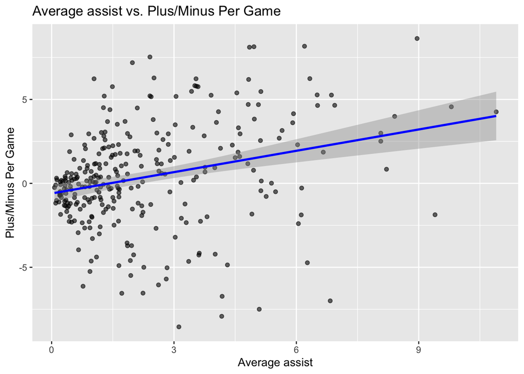

This plot shows a slight positive relationship between player assists per game and plus/minus per game. The regression line (y ~ x) indicates that plus/minus tends to increase as assists increase.

Average steals vs. Plus/Minus Per Game

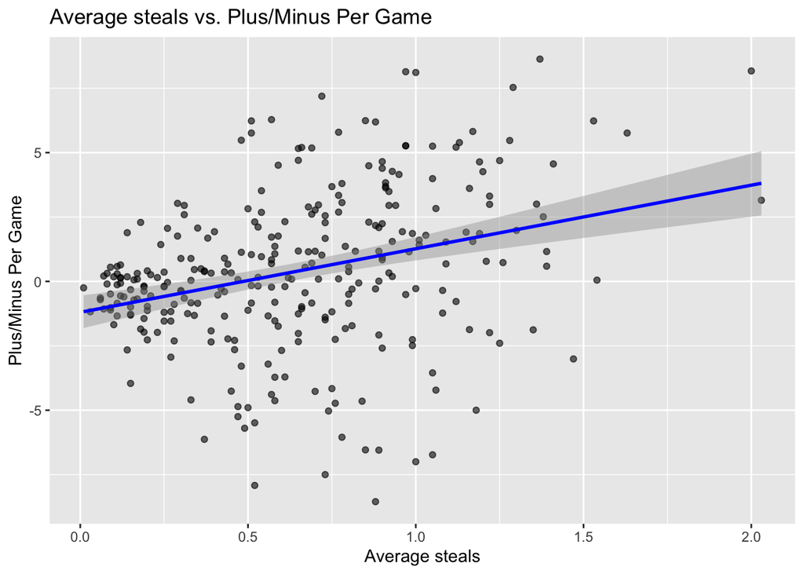

This plot shows a slight positive relationship between player steals per game and plus/minus per game. The regression line (y ~ x) indicates that plus/minus tends to increase as steals increase.

Average rebounds vs. Plus/Minus Per Game

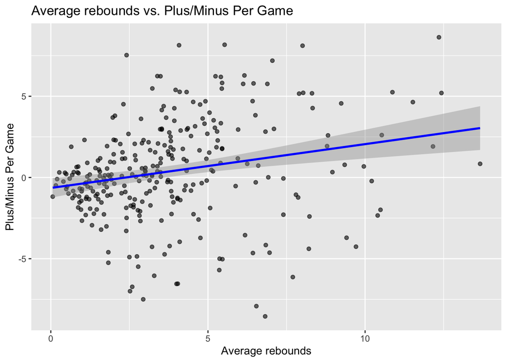

This plot shows a slight positive relationship between player rebounds per game and plus/minus per game. The regression line (y ~ x) indicates that plus/minus tends to increase as rebounds increase.

## 5. Results — Model 1: Simple Regression

### 5.1 Population Model

$$plus\_minus\_per_{i} = \beta_{0} + \beta_{1}x_i + \epsilon_i$$

$plus\_minus\_per_{i}$ - plus/minus per game for a player

$\beta_{0}$ - the plus/minus per game when player average assist is zero

$\beta_{1}$ - the predicted increase in a player’s plus/minus per game for each additional assist they average

$x_i$ - average number of assist for a player

$\epsilon_i$ - everything impacting a players plus/minus per game that isn’t average assist

### 5.2 Estimated Model

Estimated Regression Equation:

$$\widehat{plus\_minus\_per_{i}} = -0.60 + 0.42x_i + \epsilon_i$$

### 5.3 Interpretation

Coefficients:

$\beta_{0}$ - $-0.60$

If a player averages 0 assist they are expected to have an average plus/minus of $-0.60243$ per game. This makes sense because players that don’t positively impact the game by getting assist will cause their team to score less points therefor having a negative plus/minus.

The predicted change in a player’s plus/minus per game for each additional assist they average. For every 1 added assist per game the player’s plus/minus increases by 0.42. The95% confidence interval of the slope is ($\beta_{1}$) - $[0.26-0.59]$.

Model Fit:

t-value - $5.09$

degrees of freedom(df) - $293$

p-value - $6.56e-07$

$R^{2}$ - 0.081

Average assist explains about 8.1% of the variance in plus/minus per game.This is consistent with the plot showing there is a positive relationship between player assists per game and plus/minus per game but it weak. The slope is significantly different from $0$ because $p<0.05$ and the 95% confidence interval doesn’t include $0$. Therefore, $H_0$ is rejected suggesting average assists influence on plus/minus per game is not due to random chance.

### 5.4 Visualization

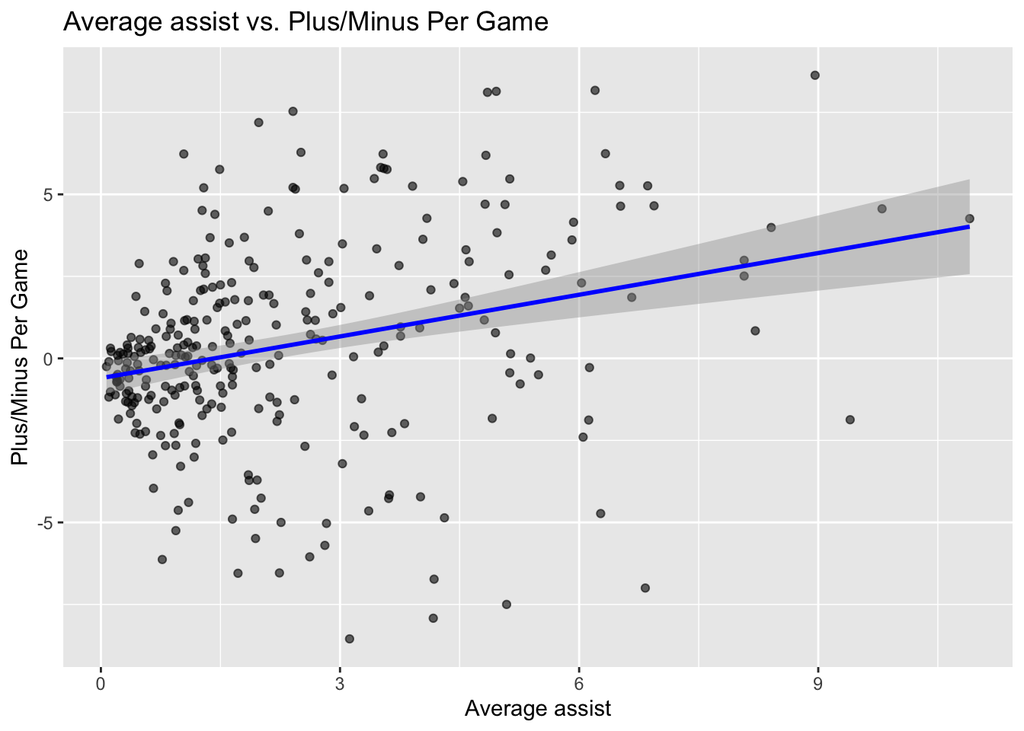

Relationship between NBA players average assist and plus/minus per game.

## 6. Results — Model 2: Multiple Regression

### 6.1 Population Model

$$plus\_minus\_per_{i} = \beta_{0} + \beta_{1}x_1 + \beta_{2}x_2 + \beta_{3}x_3 + \epsilon$$

### 6.2 Estimated Model

$$plus\_minus\_per_{i} = -1.34 + 0.17 \cdot avg\_ast + 0.10 \cdot avg\_reb + 1.50\cdot avg\_stl$$

### 6.3 Coefficient Interpretations

$\beta_{0}$ - $-1.34$

If a player averages 0 assist, rebounds, and steals they are expected to have an average plus/minus of $-1.34$ per game. This makes sense because players that don’t positively impact the game by getting assist, rebounds and steals will cause their team to score less points therefor having a negative plus/minus.

$\beta_{1}$ - $0.17$

$\beta_{2}$ - $0.10$

$\beta_{3}$ - $1.50$

### 6.4 Statistical Evidence

estimate of slope 1 ($\beta_{1}$) - $0.17$

estimate of slope 2 ($\beta_{2}$) - $0.10$

estimate of slope 3 ($\beta_{3}$) - $1.50$

95% confidence interval ($\beta_{1}$) - $[-0.06-0.40]$

95% confidence interval ($\beta_{2}$) - $[-0.05-0.25]$

95% confidence interval ($\beta_{3}$) - $[0.22-2.79]$

t-value ($\beta_{1}$) - $1.43$

t-value ($\beta_{2}$) - $1.27$

t-value ($\beta_{3}$) - $2.30$

degrees of freedom(df) - $291$

p-value ($\beta_{1}$) - $0.155$

p-value ($\beta_{2}$) - $0.204$

p-value ($\beta_{2}$) - $0.022$

### 6.5 Model Fit

$R^{2}$ - $0.110$

Adjusted $R^{2}$ - $0.101$

F-statistic - $11.98$

p-value - $2.028e-07$

The model explains about $11%$ of the variance in plus/minus per game. After adjusting for the number of predictors the explained variations is lower at $10.1%$. The model is significant at f is $11.98$ and p is $< 0.05$. Therefore, average assist, rebounds, and steals significantly predict a player’s plus/minus per game.

### 6.6 Model Comparison (Model 1 vs Model 2)

The $R^{2}$ for model 2 of $0.110$ is larger than model 1 of 0.081. This is only a slight increase of 2.9% so it is not meaningful. The slope of average assist ($\beta_{1}$) decreased from $0.42$ in model 1 to $0.17$ in model 2. Therefore, including average rebounds and steals decreased the affect size of assists but it causing to to no longer remain significant. Overall, Model 2 slightly improves model fit as it shows the shared variance explained by assist, rebounds, and steals.

## 7. Results — Model 3:

### 7.1 Population Models

Additive:

$$Y = \beta_0 + \beta_1 X_{Low} + \beta_2 X_{Medium} + \beta_3 X_{High} + \beta_4 X_{avg\_ast} + \beta_5 X_{avg\_reb} + \beta_5 X_{avg\_stl} + \epsilon$$

$\beta_0$ - mean for the for “Very Low” group by team, holding average rebounds and steals constant

$\beta_1$ - difference in mean between the “Low” and “Very Low” groups, holding average rebounds and steals constant

$\beta_2$ - difference in mean between the “Medium” and “Very Low” groups, holding average rebounds and steals constant

$\beta_3$ - difference in mean between the “High” and “Very Low” groups, holding average rebounds and steals constant

$\beta_4$ - change in plus/minus per game for 1 additional assist

$\beta_5$ - change in plus/minus per game for 1 additional rebound

$\beta_6$ - change in plus/minus per game for 1 additional steal

Interaction:

$Y = \beta_0 + \beta_1 X_{Low} + \beta_2 X_{Medium} + \beta_3 X_{High} + \beta_4 X_{(avg\_ast)} + \beta_5 X_{(avg\_reb)} + \beta_6 X_{(avg\_stl)} \dots$ $+ \beta_{28} (avg\_ast \times avg\_reb \times avg\_stl) + \beta_{29} (X_{Low} \times avg\_ast \times avg\_reb \times avg\_stl)$ $+ \beta_{30} (X_{Medium} \times avg\_ast \times avg\_reb \times avg\_stl) + \beta_{31} (X_{High} \times avg\_ast \times avg\_reb \times avg\_stl) + \epsilon$

$\beta_0$ - plus/minus per game of player in “Very Low” group with that averages, holding average rebounds and steals constant

$\beta_1$ - difference between the “Low” and “Very Low” group, holding average rebounds and steals constant

$\beta_2$ - difference between the “Medium” and “Very Low” group, holding average rebounds and steals constant

$\beta_3$ - difference between the “High” and “Very Low” group, holding average rebounds and steals constant

$\beta_4$ - change in plus/minus per game for 1 additional assist for a “Very Low” group team

$\beta_5$ - change in plus/minus per game for 1 additional rebound a “Very Low” group team

$\beta_6$ - change in plus/minus per game for 1 additional steal a “Very Low” group team

$\beta_7$ - effect of avg_ast on plus/minus for a “Low” group team

$\beta_8$ - effect of avg_reb on plus/minus for a “Low” group team

$\beta_9$ - effect of avg_stl on plus/minus for a “Low” group team

… continued for each predictor and win-group

### 7.2 Estimated Model

Interaction model:

$Y = 0.46 + -0.98 X_{Low} + -1.66 X_{Medium} + -2.01 X_{High} + -1.57 X_{(avg\_ast)} + -0.47 X_{(avg\_reb)}$ $+ -2.19 X_{(avg\_stl)} \dots + 0.09 (avg\_ast \times avg\_reb \times avg\_stl)$ $+ 0.34 (X_{Low} \times avg\_ast \times avg\_reb \times avg\_stl) + -0.001 (X_{Medium} \times avg\_ast \times avg\_reb \times avg\_stl)$ $+ -0.03 (X_{High} \times avg\_ast \times avg\_reb \times avg\_stl)$

### 7.3 Interpretation

$\beta_{0}$ - $0.46$

A player on a very low win-group team that averages 0 assist, rebounds, and steals is expected to have an average plus/minus of $0.46$ per game.

$\beta_{1}$ - $-0.98$ Difference in plus/minus between low win-group players and very low win-group players when average assist, rebounds, and steals are held constant.

$\beta_{2}$ - $-1.66$

Difference in plus/minus between medium win-group players and very low win-group players when average assist, rebounds, and steals are held constant.

$\beta_{3}$ - $-2.01$

Difference in plus/minus between high win-group players and very low win-group players when average assist, rebounds, and steals are held constant.

$\beta_{4}$ - $-1.57$

For every 1 added assist per game the player’s plus/minus decreased by $1.57$, holding average rebounds and steals constant and before considering interactions.

$\beta_{5}$ - $-0.47$

$\beta_{6}$ - $-2.19$

For every 1 added steal per game the player’s plus/minus decreased by $2.19$, holding average assist and rebounds constant and before considering interactions.

$\beta_{28}$ - $0.09$

For players on a very low win-group team every 1 added assist, rebound, and steal per game the player’s plus/minus increase by $0.09$.

$\beta_{29}$ - $0.34$

For players on a low win-group team every 1 added assist, rebound, and steal per game the player’s plus/minus increase by $0.34$.

$\beta_{30}$ - $-0.001$

For players on a medium win-group team every 1 added assist, rebound, and steal per game the player’s plus/minus decrease by $0.001$.

$\beta_{31}$ - $-0.03$

For players on a high win-group team every 1 added assist, rebound, and steal per game the player’s plus/minus decrease by $0.03$.

### 7.4 Evidence & Fit

$R^{2}$ - $0.692$

Adjusted $R^{2}$ - $0.656$

F-statistic - $19.05$

p-value - $2.2e-16$

The comparison of the additive model and interaction model shows that including the interactions significantly improves model fit, (F(25,263)=$5.69$, $p<0.001$). This indicates that the relationship between average rebound and plus/minus per game significantly varies by team win group.

### 7.5 Visualization

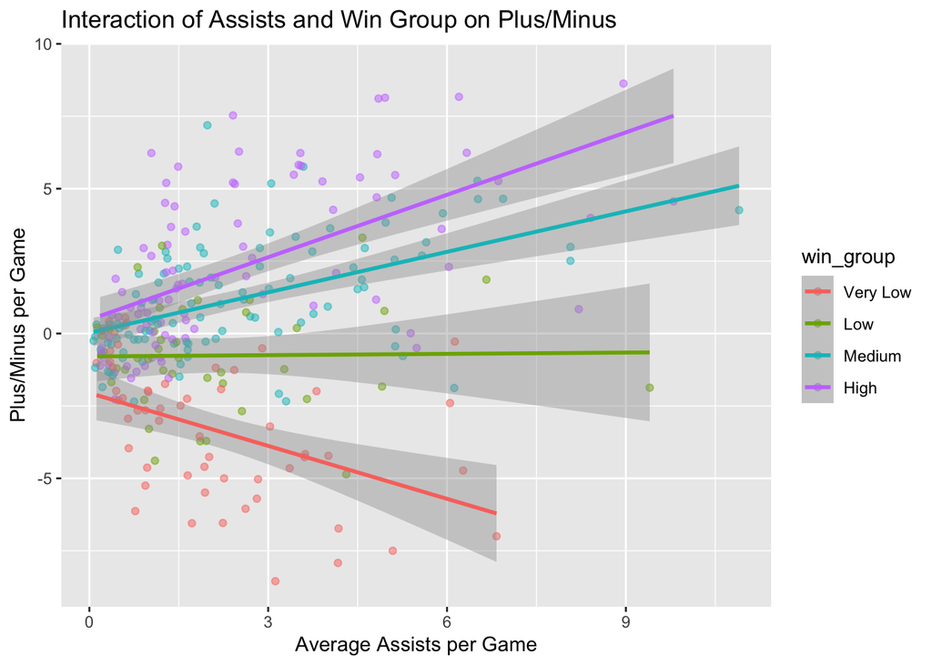

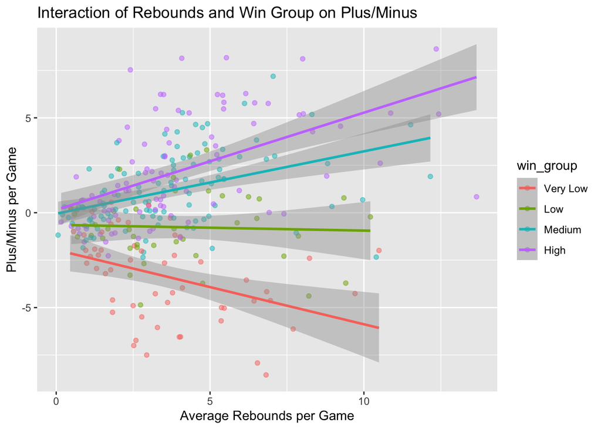

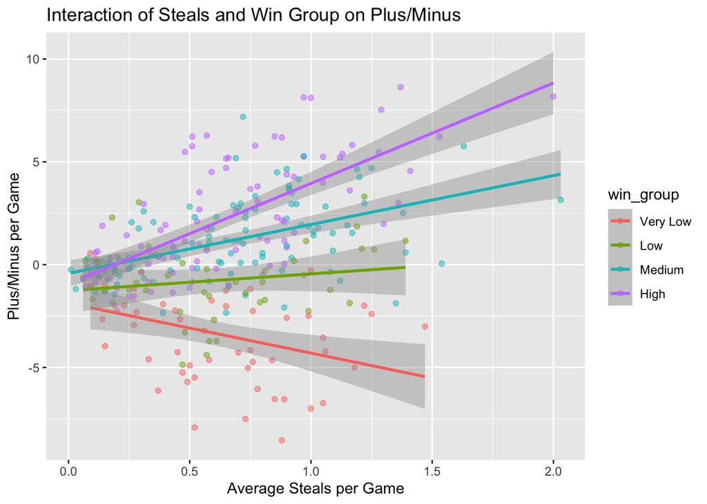

The relationship of average assist, rebounds, and steals between plus/minus per game differs across team win groups, as shown by the varying slopes.

## 8. Model Diagnostics Summary

Model 1:

Model 2:

Residuals are approximately normal, with minor negative skew and slightly heavier tails, as indicated by the histogram, Q–Q, and P–P plots. The residuals–fitted plot shows funneling, and the Breusch–Pagan test ($X^2$ = 35.40, p < 0.001) indicates heteroscedasticity, suggesting a transformation may be needed. Added-variable plots show no strong curvature and did not supporting linearity, suggesting the need for polynomial terms, splines, or transforming variables. The Durbin–Watson test (DW = 2.05, p = 0.64) indicates no autocorrelation. Multicollinearity is low all of the variable are within the tolerances and influence diagnostics flaged observations 10, 23, 32, 40, 42, and 115 but no single observation is excessively influential on the regression coefficients. Overall, assumptions are mostly met, with heteroscedasticity and non-linarity as the main concerns.

Model 3:

Residuals are approximately normal as indicated by the histogram. This is confirmed by the Q–Q and P–P plots show only slight deviations. The residuals–fitted plot shows minor funneling around 0, and the Breusch–Pagan test ($X^2$ = 3.07, p = 0.08) indicates some homoscedasticity. Added-variable plots show no strong curvature and did not supporting linearity, suggesting the need for polynomial terms, splines, or transforming variables. The Durbin–Watson test (DW = 2.05, p = 0.625) indicates no evidence of first-order autocorrelation in the residuals. Multicollinearity is high as all variables have a VIF and tolerance values outside the thresholds. Therefore, the predictors are highly correlated with each other, so it is difficult to isolate the individual effect of each variable on plus/minus per game. This may cause the regression coefficients to be unstable and standard errors to be inflated. The influence diagnostics flagged observations 22, 29, 42 and 50, but all Cook’s D values are all below the threshold of 1 indicating no excessively influential on the regression coefficients. Although, observation 22, 29, and 42 show moderate influence, indicating they have some impact on the model but are not extreme enough to require removal. Overall, the assumptions are mostly met with homoscedasticity and multicollinearity as the main concerns.

### 8.1 Normality

Model 1:

The residuals are approximately normal, as the histogram appears to be normally distributed around 0. The Q-Q plot shows minor deviations at the positive end and further deviations at the negative end. The P–P plot shows points with minor deviation between 0.2 and 0.6, indicating the data is not perfect normal in the middle-range but it is not severe enough to disprove the normality assumption.

Model 2:

The residuals are approximately normal, though the histogram and Q–Q plot suggest a slight negative (left) skew. The histogram shows a slightly heavier negative tail than the normal curve, indicating a few extreme negative residuals. The Q-Q plot shows minor deviations at the positive end and further deviations at the negative end. The P–P plot shows points with minor deviation between 0.2 and 0.6, indicating the data is not normally distributed.

Model 3:

The residuals are approximately normal, seen in the histogram and Q–Q plot. The histogram shows a normal curve. The Q-Q plot shows slight deviations at the positive and negative end. The P–P plot shows very few deviations between 0.4 and 0.6, indicating the data is not a perfect normal distributed.

### 8.2 Homoscedasticity

Model 1:

Model 2:

The residuals vs fitted values plot shows some funnelly around -1. The Breusch Pagan Test showed a p = $2.69 × 10^{-09}$ which is much smaller than $0.05$ indicating significant heteroscedasticity. This suggests that the variance of residuals is not constant across fitted values. To address this, a transformation can be applied to the response variable to stabilize the variance and potentially improve model fit.

Model 3:

The residuals vs fitted values plot shows slight funnel shape around 0. The Breusch Pagan Test showed a p = $0.08$ which is greater than $0.05$ indicating some homoscedasticity.

### 8.3 Linearity

Model 1:

The added-variable plots show heavy concentrated between the 0 and 2 with no clear linear trend. This suggests that the conditional mean of average assist does not strongly related to this plus/minus per game in a linear fashion. This suggest the need for polynomial terms, splines, or transforming variables.

Model 2:

The added-variable plots show heavy concentrated near the center of the predictor range with no clear linear trend. This suggests that the conditional mean of the predictors do not strongly related to plus/minus per game in a linear fashion. This suggest the need for polynomial terms, splines, or transforming variables.

Model 3:

The added-variable plots show dispersed points for each win group with no clear linear trend. This suggests that the conditional mean of the predictors do not strongly related to plus/minus per game in a linear fashion. This suggest the need for polynomial terms, splines, or transforming variables.

### 8.4 Autocorrelation

Model 1:

The Durbin–Watson test (DW = 2.04, p = 0.61) does not indicate first-order autocorrelation in the residuals, suggesting that the residuals are independent and standard regression inference is valid.

Model 2:

The Durbin–Watson test (DW = 2.05, p = 0.64) does not indicate first-order autocorrelation in the residuals, suggesting that the residuals are independent and standard regression inference is valid.

Model 3:

The Durbin–Watson test (DW = 2.05, p = 0.625) indicates there is no evidence of first-order autocorrelation in the residuals. This suggest the independence assumption is satisfied.

### 8.5 Multicollinearity

Model 2: All of the variable have a VIF bellow 10 and tolerance above 0.10 indicating that multicollinearity is not a concern for the predictors.

Model 3:

All of the variable have a VIF above 10 and tolerance below 0.10. This means the predictors are highly correlated with each other, so it is difficult to isolate the individual effect of each variable on plus/minus per game. This may cause regression the coefficients to be unstable and standard errors to be inflated. Therefore, reducing the reliability of significance tests.

### 8.6 Influence

Model 1: Observations 22 and 32 (Hat > 2p/n) have high leverage, meaning they have unusual predictor values and could potentially influence the regression fit. Studentized residuals flag observations 40 and 115 as potential outliers (|t| > 3), since their responses deviate substantially from the model’s predictions. Cook’s D values for all observations are far below 1, indicating that no single observation is excessively influential on the regression coefficients. Overall, while a few points have high leverage or large residuals, there are no extreme cases that unduly distort the model.

Model 2: Observations 10, 32, and 42 (h > 2p/n) have reletively high leverage and could influence the fitted regression model. Studentized residuals identify observations 23, 40, and 115 as potential outliers (|t| > 3), because their responses are unusually far from the model predictions. However, Cook’s D values are all far below the threshold of 1. This suggests that no single observation is excessively influential on the regression coefficients.

Model 3:

Observations 22, 29, 42 and 50 (h > 2p/n) have fairly high leverage, indicating they have unusual predictor values that could influence the regression fit. Studentized residuals identify observations 37 and 50 as potential outliers (|t| > 3), because their responses are unusually far from the model predictions. However, all Cook’s D values are all below the threshold of 1. This suggests that no single observation is excessively influential on the regression coefficients. Although, observation 22, 29, and 42 show moderate influence, indicating they have some impact on the model but are not extreme enough to require removal. Overall, the regression appears robust, though a few points exhibit higher leverage or residuals.

## 9. Discussion

### 9.4 Directions for Future Analysis

Future research should investigate the nonlinear relationships to discover any further relationships. Additional predictors such as style, usage rate, lineup, and opponent strength may provide more in-depth insight into how player contributions affect plus/minus. Methodologically, cross-validation, regularization, and transformation can reduce over fitting and better handle complex interactions. Also, standardization can be applied to adjust for the smaller scale of steals.

## 10. References

Carey, M. (2024). hoopR: Access Men’s and Women’s Basketball Play-by-Play Data. R package version X.X.X. https://github.com/sportsdataverse/hoopR